# Name: Jahwanza Knight - Log-Rank/ Trend Test

1. The officials want to compare the hazard of re-incarceration among the 4 programs.
   - Conduct a “regular” log rank test.
   - Conduct a log rank test, stratified by prison unit.
   - Conduct a log rank test, stratified by age at incarceration, with age categorized as 18-25, and older than 25. (You will need to create this categorization.)
   - Conduct a log rank trend test. The scores for this trend test need to be defined by the proportion of individuals enrolled in each program that have a psychiatric condition.
2. The officials want to compare the hazard of re-incarceration among the 5 groups defined by severity of offense.
   - Conduct a “regular” log rank test.
   - Conduct a log rank trend test, with integer scores for the 5 severity levels (i.e. the numbers 1 through 5).
3. Conduct a matched pairs log rank test to compare the hazard of re-incarceration between the primary and accessory member of each pair. (NOTE: Observations in the data set with NA for the pair and pair.type variables are not involved in this comparison).

```r
library(tidyverse)
library(survival)
library(KMsurv)
library(survminer)
load("D:/Documents/BioStatistics/SURVIVAL ANAL/Recidivism.RData")
```

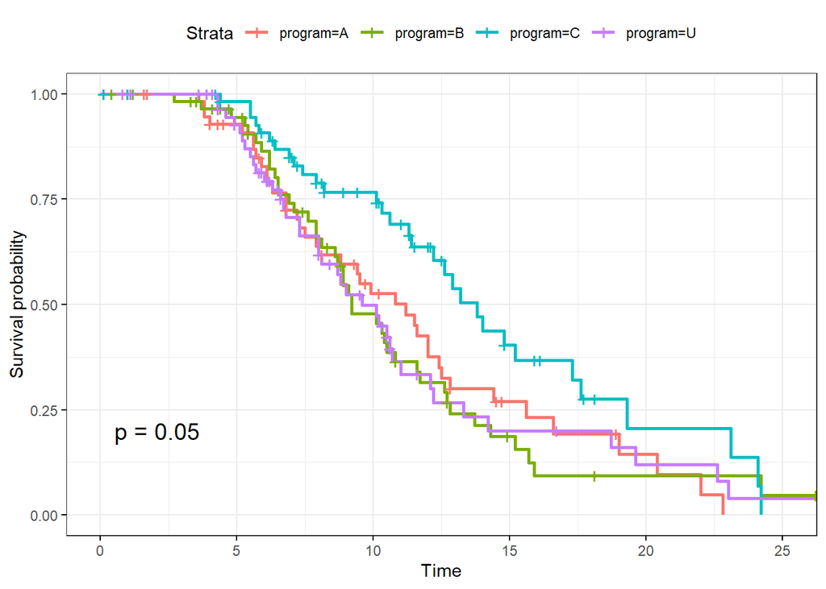

```r
dat2<- dat %>% arrange(time,desc(event)) %>% mutate(age_grp=if_else(age.incarc <= 25,"18-25",">25"))
dat2$age_grp<- factor(dat2$age_grp,levels = c("18-25",">25"))
surv_object <- Surv(time = dat2$time, event = dat2$event)

ggsurvplot(survfit(surv_object~program,data = dat2),pval = TRUE,ggtheme = theme_bw())
```

The log-rank test of the data gives $X2=7.8$ on 3 d.g of freedom p-val=0.049. therefore the we could reject the $H0$ and claim that the there is at least one statistically significant difference between the programs survival time. The graphical plot shows that program C has a survival time that is higher than the other groups.

```r
#log rank test
test1<-survdiff(surv_object~program,data = dat2);test1
```

```
Call:
survdiff(formula = surv_object ~ program, data = dat2)

           N Observed Expected (O-E)^2/E (O-E)^2/V
program=A 60       39     35.1     0.435     0.581
program=B 60       41     34.8     1.104     1.476
program=C 60       31     46.6     5.214     7.730
program=U 60       39     33.5     0.895     1.204

 Chisq= 7.8  on 3 degrees of freedom, p= 0.05
```

```r
test1$pvalue
```

```
[1] 0.04971397
```

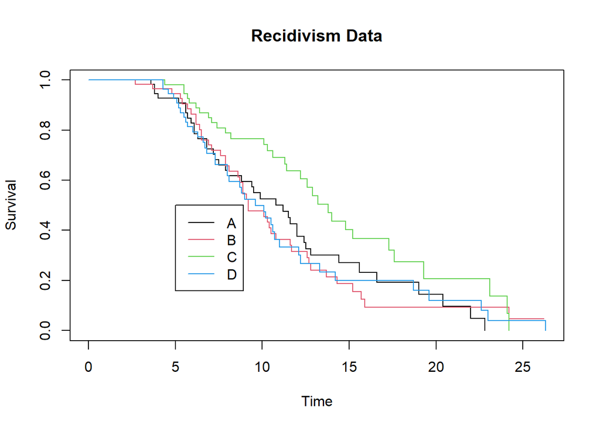

```r
fit1<- survfit(surv_object~program,data = dat2)
plot(fit1, xlab="Time", ylab="Survival", main="Recidivism Data", col=1:4)
legend(5, .5, legend=c("A","B","C","D"), lty=1, col=1:4)
```

```r
par(mfrow=c(1,2))
```

Program C appears to be the best at reducing re-incarceration however police units does not seem to create a statistical difference

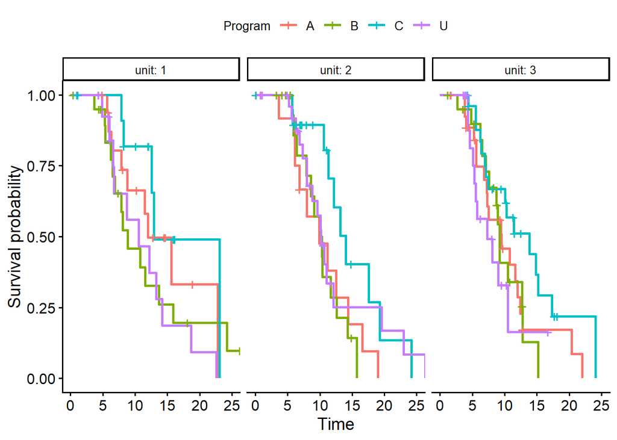

```r
#stratified by unit
by.unit<-ggsurvplot_facet(survfit(surv_object~program+unit,data = dat2),data=dat2,facet.by='unit',legend.title = "Program");

by.unit
```

```r
survdiff(surv_object~program,data = dat2,subset = unit==1)
```

```
Call:
survdiff(formula = surv_object ~ program, data = dat2, subset = unit ==
    1)

           N Observed Expected (O-E)^2/E (O-E)^2/V
program=A 18        9    10.50     0.214     0.301
program=B 21       14    12.05     0.317     0.504
program=C 13        5     9.11     1.854     2.469
program=U 14       11     7.35     1.817     2.300

 Chisq= 4.3  on 3 degrees of freedom, p= 0.2
```

```r
survdiff(surv_object~program,data = dat2,subset = unit==2)
```

```
Call:
survdiff(formula = surv_object ~ program, data = dat2, subset = unit ==
    2)

           N Observed Expected (O-E)^2/E (O-E)^2/V
program=A 14       11     8.26     0.912    1.1243
program=B 18       13     9.28     1.487    1.9174
program=C 20       10    15.77     2.111    3.1417
program=U 27       17    17.69     0.027    0.0458

 Chisq= 4.7  on 3 degrees of freedom, p= 0.2
```

```r
survdiff(surv_object~program,data = dat2,subset = unit==3)
```

```
Call:
survdiff(formula = surv_object ~ program, data = dat2, subset = unit ==
    3)

           N Observed Expected (O-E)^2/E (O-E)^2/V
program=A 28       19    16.89     0.263     0.382
program=B 21       14    12.21     0.262     0.343
program=C 27       16    23.52     2.405     4.255
program=U 19       11     7.38     1.779     2.113

 Chisq= 5.1  on 3 degrees of freedom, p= 0.2
```

```r
test2<-survdiff(surv_object~program+unit,data = dat2)
test2
```

```
Call:
survdiff(formula = surv_object ~ program + unit, data = dat2)

                   N Observed Expected (O-E)^2/E (O-E)^2/V
program=A, unit=1 18        9    13.38    1.4317     1.594
program=A, unit=2 14       11     8.15    0.9934     1.065
program=A, unit=3 28       19    13.56    2.1808     2.438
program=B, unit=1 21       14    15.18    0.0919     0.109
program=B, unit=2 18       13     9.71    1.1138     1.213
program=B, unit=3 21       14     9.91    1.6897     1.855
program=C, unit=1 13        5    11.31    3.5213     3.864
program=C, unit=2 20       10    15.96    2.2234     2.544
program=C, unit=3 27       16    19.32    0.5699     0.663
program=U, unit=1 14       11     9.42    0.2634     0.285
program=U, unit=2 27       17    18.36    0.1011     0.125
program=U, unit=3 19       11     5.74    4.8313     5.126

 Chisq= 19.8  on 11 degrees of freedom, p= 0.05
```

```r
survdiff(surv_object~program+strata(unit),data = dat2)
```

```
Call:
survdiff(formula = surv_object ~ program + strata(unit), data = dat2)

           N Observed Expected (O-E)^2/E (O-E)^2/V
program=A 60       39     35.6     0.316     0.436
program=B 60       41     33.5     1.658     2.308
program=C 60       31     48.4     6.255     9.853
program=U 60       39     32.4     1.338     1.933

 Chisq= 10.3  on 3 degrees of freedom, p= 0.02
```

```r
#Conduct a log rank test, stratified by age at incarceration, with age categorized as 18-25, and older than 25. (You will need to create this categorization.)


age.fit<-survdiff(surv_object~age_grp,data=dat2)
age.fit$pvalue
```

```
[1] 0.6019002
```

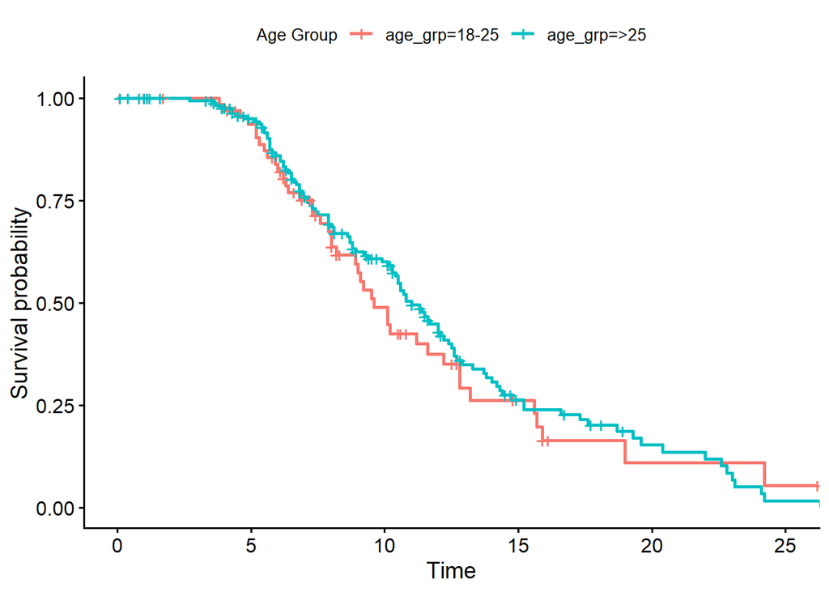

```r
ggsurvplot(survfit(surv_object~age_grp,data=dat2),legend.title = "Age Group")
```

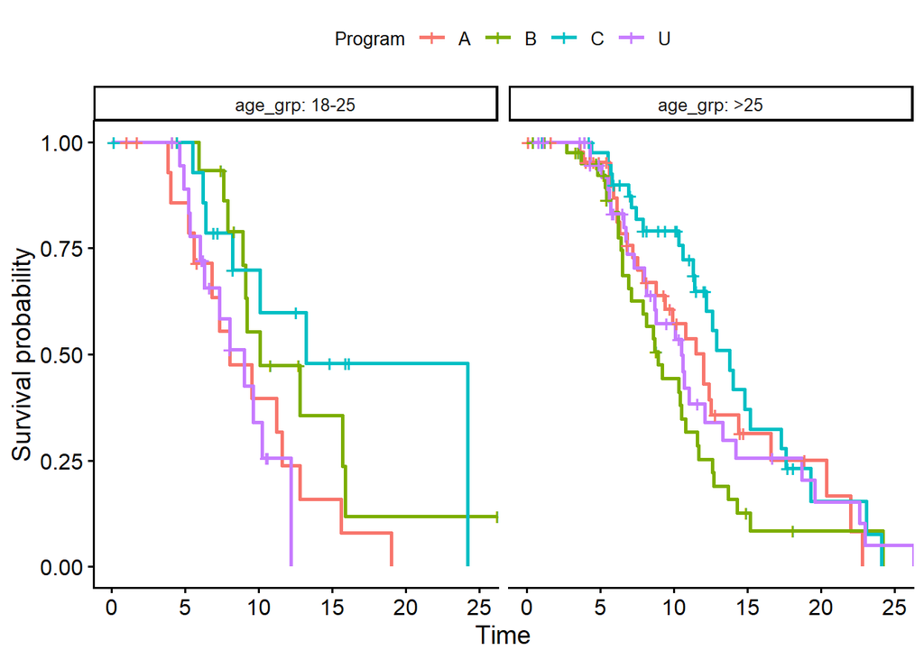

```r
ggsurvplot_facet(survfit(surv_object~program+age_grp,data = dat2),data=dat2,facet.by='age_grp',legend.title = "Program")
```

```r
survdiff(surv_object~program+strata(age_grp),data = dat2)
```

```
Call:
survdiff(formula = surv_object ~ program + strata(age_grp), data = dat2)

           N Observed Expected (O-E)^2/E (O-E)^2/V
program=A 60       39     35.1     0.430     0.577
program=B 60       41     34.7     1.152     1.556
program=C 60       31     46.1     4.934     7.318
program=U 60       39     34.1     0.695     0.958

 Chisq= 7.4  on 3 degrees of freedom, p= 0.06
```

The log-rank trend test provides a p-val=0.3 > 0.05 so we have failed to reject the $H0:$ for the log rank-trend test and can conclude that the hazards of the re-incarceration rates are equal between those with and without psychiatric condition.

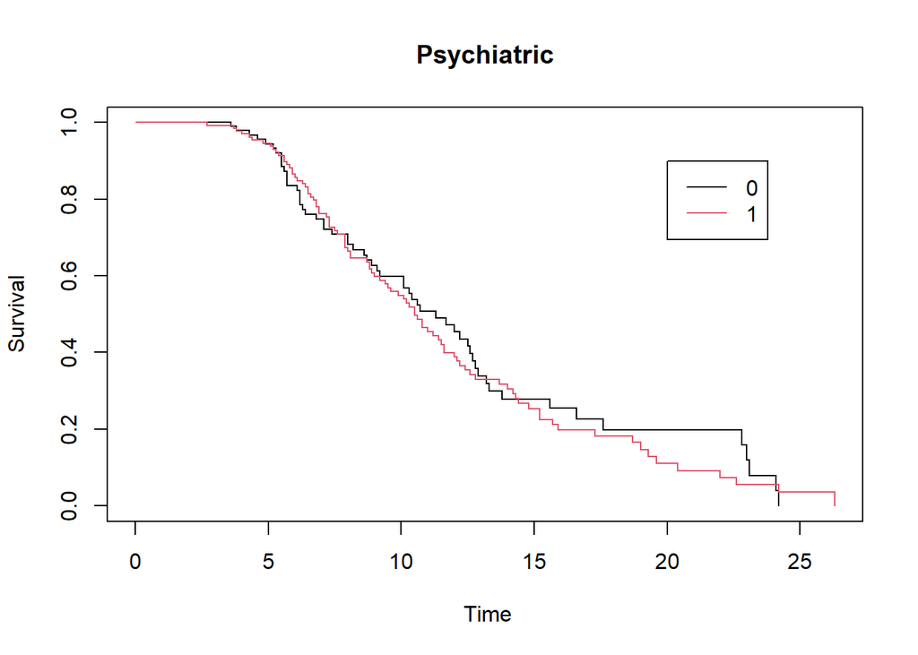

```r
#Conduct a log rank trend test. The scores for this trend test need to be defined by the proportion of individuals enrolled in each program that have a psychiatric condition.

trend.test <- function(obj, scr) {
  z <- obj$obs-obj$exp
  v <- obj$var
  num <- sum(scr*z)
  denom <- as.numeric(sqrt(t(scr) %*% v %*% scr))
  stat <- num/denom
  p <- 1-pnorm(stat)
  return(list(statistic=stat,p.value=p))
}

psych.fit<-surv_fit(surv_object~psych,data=dat2)
plot(psych.fit,xlab = " Time",ylab = "Survival",main="Psychiatric",col = 1:2)
legend(20, .9, legend=c('0','1'), lty=1, col=1:2)
```

```r
psych.diff<-survdiff(surv_object~psych,data=dat2)
group_prop <- psych.diff$n / sum(psych.diff$n)
trend.test(psych.diff, group_prop)
```

```
$statistic
[1] 0.4526794

$p.value
[1] 0.3253898
```

1. The officials want to compare the hazard of re-incarceration among the 5 groups defined by severity of offense.

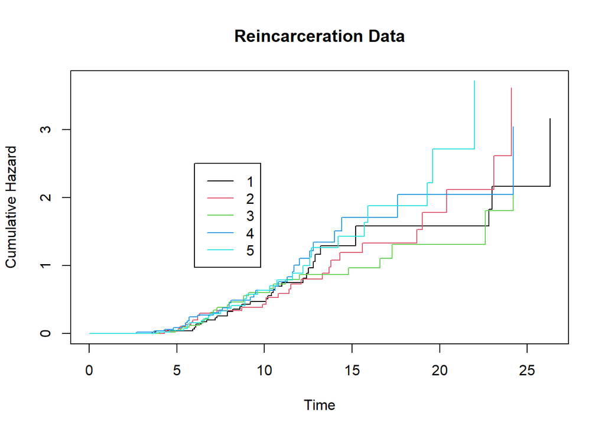

```r
haz1<-survfit(Surv(time = dat2$time, event = dat2$event)~sev,data=dat2)
plot(haz1, fun="cumhaz", xlab="Time", ylab="Cumulative Hazard", main="Reincarceration Data", conf.int=F,col=1:5)
legend(6, 2.5, legend=c("1","2","3","4",'5'), lty=1, col=1:5)
```

```r
##regular log rank
haz.log<-survdiff(surv_object~sev,data = dat2)
haz.log$pval
```

```
[1] 0.6079861
```

```r
#
trend.test(haz.log, 1:5)
```

```
$statistic
[1] 1.347099

$p.value
[1] 0.08897416
```

comparing the matched pairs in a log test we get a Chisq= 0.7 on 1 degrees of freedom, p= 0.4 >0.05 . No significant difference between accessory and primary pairing

```r
#A small subset of prisoners were paired together, having been convicted of the same crime. In each of these pairs, one of the prisoners was the “primary” perpetrator of the crime, and the other was the “accessory” to the crime.
#Conduct a matched pairs log rank test to compare the hazard of re-incarceration between the primary and accessory member of each pair. (NOTE: Observations in the data set with NA for the pair and pair.type variables are not involved in this comparison).

matched<- dat2[!is.na(dat2$pair),]

pair.test<- survdiff(Surv(time,event)~ pair.type+strata(pair),data = matched)
pair.test
```

```
Call:
survdiff(formula = Surv(time, event) ~ pair.type + strata(pair),
    data = matched)

                     N Observed Expected (O-E)^2/E (O-E)^2/V
pair.type=Accessory 23       14     12.5      0.18     0.692
pair.type=Primary   23       11     12.5      0.18     0.692

 Chisq= 0.7  on 1 degrees of freedom, p= 0.4
```

```r
survdiff(Surv(time,event)~ pair.type,data = matched)
```

```
Call:
survdiff(formula = Surv(time, event) ~ pair.type, data = matched)

                     N Observed Expected (O-E)^2/E (O-E)^2/V
pair.type=Accessory 23       14     10.2     1.396      2.65
pair.type=Primary   23       11     14.8     0.966      2.65

 Chisq= 2.7  on 1 degrees of freedom, p= 0.1
```

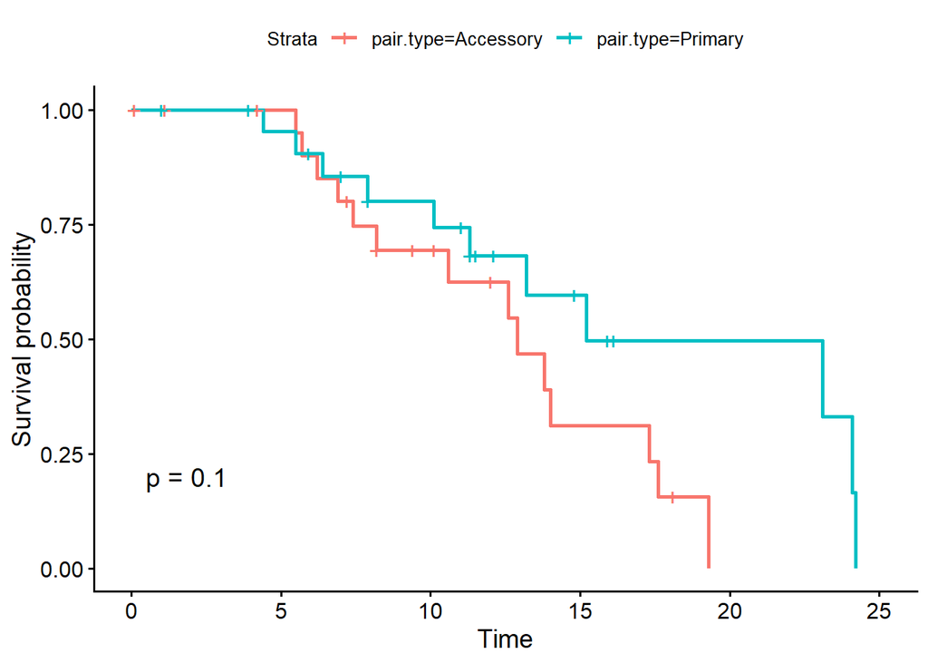

```r
ggsurvplot(survfit(Surv(time,event)~ pair.type,data = matched),data = matched, pval = TRUE)
```

```r
matched<- dat2[!is.na(dat2$pair),]

pair.test<- survdiff(Surv(time,event)~ pair.type+strata(pair),data = matched)
pair.test
```

```
Call:
survdiff(formula = Surv(time, event) ~ pair.type + strata(pair),
    data = matched)

                     N Observed Expected (O-E)^2/E (O-E)^2/V
pair.type=Accessory 23       14     12.5      0.18     0.692
pair.type=Primary   23       11     12.5      0.18     0.692

 Chisq= 0.7  on 1 degrees of freedom, p= 0.4
```

```r
survdiff(Surv(time,event)~ pair.type,data = matched)
```

```
Call:
survdiff(formula = Surv(time, event) ~ pair.type, data = matched)

                     N Observed Expected (O-E)^2/E (O-E)^2/V
pair.type=Accessory 23       14     10.2     1.396      2.65
pair.type=Primary   23       11     14.8     0.966      2.65

 Chisq= 2.7  on 1 degrees of freedom, p= 0.1
```

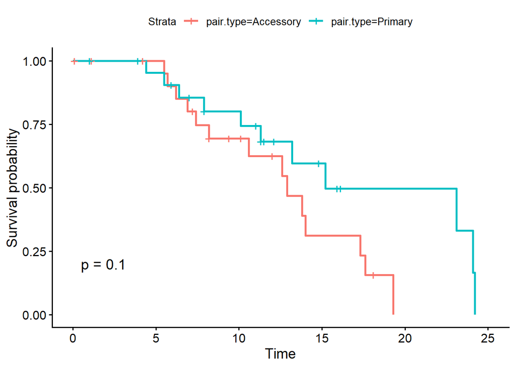

```r
ggsurvplot(survfit(Surv(time,event)~ pair.type,data = matched),data = matched, pval = TRUE)
```

[output not shown]